# Covid-19 on Claim Inflation

Henry Zhang

2023-07-22

With recent global events such as the Covid-19 Pandemic, Claim Inflation - the fluctuation of the frequency and size of claim payments around goods and services have inevitably become a pressing issue for insurance companies. The effects of the recent pandemic have resulted in large disruptions to the global supply chain especially for motor insurance, which has seen increases in claim inflation due to shortages in both the supply chain and in the workforce.

Given the instability of post-Covid claims experience, our goal is to augment standard actuarial GLM models with external macroeconomic indicators to better capture inflation drivers and reduce prediction uncertainty.

The work covers:

- Outlier detection
- Feature engineering
- Joining external macroeconomic datasets
- Frequency modelling (Poisson)
- Severity modelling (Gamma – log link)

## Loading Libraries

```r
library(tidyverse)
library(lubridate)
library(zoo)
library(MASS)
library(caret)
library(leaps)
library(reshape2)
```

## Reading and Cleaning Claim data

```r
raw <- read.csv("claims.csv", fileEncoding = "UTF-8-BOM")

# examining structure
str(raw)
```

```
## 'data.frame':    1226044 obs. of  13 variables:
##  $ accident_month     : chr  "2020-06-30" "2020-07-31" "2020-08-31" "2020-09-30" ...
##  $ term_start_date    : chr  "2020-06-16 00:00:00+10" "2020-06-16 00:00:00+10" "2020-06-16 00:00:00+10" "2020-06-16 00:00:00+10" ...
##  $ term_expiry_date   : chr  "2021-06-16 00:00:00+10" "2021-06-16 00:00:00+10" "2021-06-16 00:00:00+10" "2021-06-16 00:00:00+10" ...
##  $ policy_id          : int  1 1 1 1 1 1 1 1 1 1 ...
##  $ policy_tenure      : int  0 0 0 0 0 0 0 0 0 0 ...
##  $ sum_insured        : int  24550 24550 24550 24550 24550 24550 24550 24550 24550 24550 ...
##  $ risk_state_name    : chr  "NSW" "NSW" "NSW" "NSW" ...
##  $ risk_postcode      : int  2483 2483 2483 2483 2483 2483 2483 2483 2483 2483 ...
##  $ year_of_manufacture: int  2008 2008 2008 2008 2008 2008 2008 2008 2008 2008 ...
##  $ vehicle_class      : chr  "Class 14" "Class 14" "Class 14" "Class 14" ...
##  $ claim_loss_date    : chr  "" "" "" "" ...
##  $ exposure           : num  0.0411 0.0849 0.0849 0.0822 0.0849 ...
##  $ total_claims_cost  : int  NA NA NA NA NA NA NA NA NA NA ...
```

Claims represents historical motor insurance claims including policy information, claim costs, vehicle and claimant information. It has 1226044 rows and 13 variables. Each row represents the policy for a month.

| Variable | Type | Description |
| --- | --- | --- |
| `accident_month` | Date | Month of claim occurrence or exposure period. |
| `term_start_date` | Datetime (string) | Policy inception date/time. |
| `term_expiry_date` | Datetime (string) | Policy expiry date/time. |
| `policy_id` | Integer | Unique policy identifier. |
| `policy_tenure` | Integer | Years the policy has been active. |
| `sum_insured` | Integer | Agreed vehicle value in AUD. |
| `risk_state_name` | Categorical (8 levels) | State/territory of risk location. |
| `risk_postcode` | Integer | Postcode of insured risk. |
| `year_of_manufacture` | Integer | Year vehicle was built. |
| `vehicle_class` | Categorical (15 levels) | Classification of vehicle type. |
| `claim_loss_date` | String | Date of loss if claim occurred. Empty if no claim. |
| `exposure` | Numeric | Policy exposure fraction for the year. |
| `total_claims_cost` | Numeric | Total cost of all claims in that month. |

```r
claims <- raw %>%
  mutate(
    # Date Features
    accident_month = floor_date(as.Date(accident_month), "month"),
    # floored to align with external data
    term_start_date = ymd_hms(term_start_date),
    term_expiry_date = ymd_hms(term_expiry_date),
    claim_loss_date = ymd_hms(claim_loss_date),

    # Engineered featuyres
    vehicle_age = year(accident_month) - year_of_manufacture,
    accident_year = year(accident_month),
    accident_month_num = month(accident_month),

    # Frequency Target
    claim_count = ifelse(!is.na(total_claims_cost) & total_claims_cost > 0, 1 , 0),

    # Categorical fields
    vehicle_class = as.factor(vehicle_class),
    risk_state_name = as.factor(risk_state_name),

  )
```

Some basic feature engineering, and converting fields to their proper types.

### External Data

External macroeconomic data (petrol, unemployment, gold) and quarterly indicies (CPI, wage index) were add to the dataset to capture external factors that may influence claim costs.

```r
monthly <- read.csv("monthly.csv", fileEncoding = "UTF-8-BOM") %>%
  mutate(
    accident_month = dmy(Date)
  ) %>%
  dplyr::select(accident_month, petrol, unemployment, gold)

quarterly <- read.csv("quarterly.csv", fileEncoding = "UTF-8-BOM") %>%
  mutate(
    accident_month = dmy(Date),
    Quarter = as.yearqtr(accident_month)
  ) %>%
  dplyr::select(Quarter, transport_cpi, motor_cpi, parts_cpi, repair_cpi, wage_index)

external_data <- monthly %>%
  mutate(Quarter = as.yearqtr(accident_month)) %>%
  left_join(quarterly, by = "Quarter")
external_data$Quarter <- as.factor(external_data$Quarter)

str(external_data)
```

```
## 'data.frame':    60 obs. of  10 variables:
##  $ accident_month: Date, format: "2016-07-01" "2016-08-01" "2016-09-01" "2016-10-01" ...
##  $ petrol        : num  104 102 107 110 109 ...
##  $ unemployment  : num  5.58 5.61 5.51 5.34 5.37 ...
##  $ gold          : num  1342 1309 1322 1272 1178 ...
##  $ Quarter       : Factor w/ 20 levels "2016 Q3","2016 Q4",..: 1 1 1 2 2 2 3 3 3 4 ...
##  $ transport_cpi : num  97.7 97.7 97.7 99.4 99.4 ...
##  $ motor_cpi     : num  94.4 94.4 94.4 93.8 93.8 93.8 93.5 93.5 93.5 93.8 ...
##  $ parts_cpi     : num  107 107 107 107 107 ...
##  $ repair_cpi    : num  108 108 108 108 108 ...
##  $ wage_index    : num  125 125 125 125 125 ...
```

```r
summary(external_data)
```

```
##  accident_month           petrol        unemployment        gold         Quarter   transport_cpi     motor_cpi
##  Min.   :2016-07-01   Min.   : 83.19   Min.   :4.746   Min.   :1146   2016 Q3: 3   Min.   : 97.7   Min.   : 91.30
##  1st Qu.:2017-09-23   1st Qu.:109.96   1st Qu.:5.173   1st Qu.:1270   2016 Q4: 3   1st Qu.:100.8   1st Qu.: 93.45
##  Median :2018-12-16   Median :119.27   Median :5.472   Median :1321   2017 Q1: 3   Median :103.8   Median : 93.80
##  Mean   :2018-12-16   Mean   :119.34   Mean   :5.627   Mean   :1448   2017 Q2: 3   Mean   :103.9   Mean   : 94.50
##  3rd Qu.:2020-03-08   3rd Qu.:129.48   3rd Qu.:5.995   3rd Qu.:1630   2017 Q3: 3   3rd Qu.:106.6   3rd Qu.: 94.85
##  Max.   :2021-06-01   Max.   :143.33   Max.   :7.385   Max.   :1965   2017 Q4: 3   Max.   :109.9   Max.   :101.20
##                                                                       (Other):42
##    parts_cpi       repair_cpi      wage_index
##  Min.   :106.7   Min.   :107.8   Min.   :124.6
##  1st Qu.:109.2   1st Qu.:108.8   1st Qu.:127.5
##  Median :111.0   Median :111.8   Median :130.9
##  Mean   :110.6   Mean   :112.5   Mean   :130.7
##  3rd Qu.:112.2   3rd Qu.:116.1   3rd Qu.:134.1
##  Max.   :113.6   Max.   :119.3   Max.   :136.5
##
```

| Variable | Type | Description |
| --- | --- | --- |
| `accident_month` | Date | First day of the month for macroeconomic observation. Used to align with claim month. |
| `petrol` | Numeric | Average petrol price for the month (AUD). |
| `unemployment` | Numeric | Monthly unemployment rate (%) |
| `gold` | Numeric | Average gold price for the month (AUD/oz). |
| `Quarter` | Year-Quarter (`yearqtr`) | Quarter of the year (e.g., 2016 Q3). |
| `transport_cpi` | Numeric | Transport component of the Consumer Price Index (CPI). |
| `motor_cpi` | Numeric | Motor vehicle CPI component for the month. |
| `parts_cpi` | Numeric | CPI index for vehicle parts and components. |
| `repair_cpi` | Numeric | CPI index for vehicle repair costs. |
| `wage_index` | Numeric | Wage index representing average wage levels, for inflation adjustment. |

```r
claims_combined <- claims %>%
  left_join(external_data, by = "accident_month")
```

## EDA

```r
summary(claims_combined)
```

```
##  accident_month       term_start_date                  term_expiry_date                   policy_id     policy_tenure
##  Min.   :2016-07-01   Min.   :2015-07-01 14:00:00.00   Min.   :2016-06-30 14:00:00.00   Min.   :    1   Min.   : 0.000
##  1st Qu.:2017-09-01   1st Qu.:2017-04-08 14:00:00.00   1st Qu.:2018-03-26 13:00:00.00   1st Qu.:10304   1st Qu.: 3.000
##  Median :2018-12-01   Median :2018-06-25 14:00:00.00   Median :2019-06-10 14:00:00.00   Median :20693   Median : 7.000
##  Mean   :2018-12-01   Mean   :2018-06-28 09:15:01.78   Mean   :2019-06-06 22:53:30.85   Mean   :20653   Mean   : 9.161
##  3rd Qu.:2020-03-01   3rd Qu.:2019-09-12 14:00:00.00   3rd Qu.:2020-08-22 14:00:00.00   3rd Qu.:30988   3rd Qu.:14.000
##  Max.   :2021-06-01   Max.   :2021-06-29 14:00:00.00   Max.   :2022-08-19 14:00:00.00   Max.   :41109   Max.   :39.000
##
##   sum_insured      risk_state_name  risk_postcode  year_of_manufacture  vehicle_class
##  Min.   :    350   WA     :364920   Min.   : 810   Min.   :1900        Class 14:488246
##  1st Qu.:  12450   VIC    :356575   1st Qu.:3388   1st Qu.:2004        Class 8 :214951
##  Median :  26850   SA     :218258   Median :4871   Median :2009        Class 12:125239
##  Mean   :  41861   QLD    :141066   Mean   :4691   Mean   :2007        Class 9 : 97917
##  3rd Qu.:  48450   NSW    :121081   3rd Qu.:6084   3rd Qu.:2014        Class 13: 67997
##  Max.   :2491856   TAS    : 22943   Max.   :7330   Max.   :2021        Class 15: 48528
##                    (Other):  1201                                      (Other) :183166
##  claim_loss_date                     exposure       total_claims_cost  vehicle_age     accident_year  accident_month_num
##  Min.   :2016-06-30 14:00:00.00   Min.   :0.00000   Min.   :     0    Min.   : -1.00   Min.   :2016   Min.   : 1.000
##  1st Qu.:2017-08-06 14:00:00.00   1st Qu.:0.08219   1st Qu.:   540    1st Qu.:  5.00   1st Qu.:2017   1st Qu.: 4.000
##  Median :2018-09-26 14:00:00.00   Median :0.08219   Median :  2962    Median :  9.00   Median :2018   Median : 7.000
##  Mean   :2018-10-30 20:52:53.48   Mean   :0.07647   Mean   :  6373    Mean   : 11.07   Mean   :2018   Mean   : 6.504
##  3rd Qu.:2020-01-05 13:00:00.00   3rd Qu.:0.08493   3rd Qu.:  7199    3rd Qu.: 15.00   3rd Qu.:2020   3rd Qu.: 9.000
##  Max.   :2021-06-29 14:00:00.00   Max.   :0.08493   Max.   :383018    Max.   :121.00   Max.   :2021   Max.   :12.000
##  NA's   :1218397                                    NA's   :1218397
##   claim_count           petrol        unemployment        gold         Quarter       transport_cpi     motor_cpi
##  Min.   :0.000000   Min.   : 83.19   Min.   :4.746   Min.   :1146   2018 Q2: 64073   Min.   : 97.7   Min.   : 91.30
##  1st Qu.:0.000000   1st Qu.:110.28   1st Qu.:5.174   1st Qu.:1268   2017 Q2: 63544   1st Qu.:100.3   1st Qu.: 93.30
##  Median :0.000000   Median :119.33   Median :5.453   Median :1319   2016 Q3: 63184   Median :103.8   Median : 93.80
##  Mean   :0.005425   Mean   :119.44   Mean   :5.618   Mean   :1441   2018 Q3: 63107   Mean   :103.9   Mean   : 94.44
##  3rd Qu.:0.000000   3rd Qu.:129.83   3rd Qu.:5.979   3rd Qu.:1610   2017 Q3: 62958   3rd Qu.:106.5   3rd Qu.: 94.80
##  Max.   :1.000000   Max.   :143.33   Max.   :7.385   Max.   :1965   2018 Q1: 62900   Max.   :109.9   Max.   :101.20
##                                                                     (Other):846278
##    parts_cpi       repair_cpi      wage_index
##  Min.   :106.7   Min.   :107.8   Min.   :124.6
##  1st Qu.:108.8   1st Qu.:108.5   1st Qu.:127.1
##  Median :110.8   Median :111.5   Median :130.6
##  Mean   :110.5   Mean   :112.4   Mean   :130.6
##  3rd Qu.:112.0   3rd Qu.:115.9   3rd Qu.:134.1
##  Max.   :113.6   Max.   :119.3   Max.   :136.5
##
```

```r
sapply(claims_combined, function(x) sum(is.na(x)))
```

```
##      accident_month     term_start_date    term_expiry_date           policy_id       policy_tenure         sum_insured
##                   0                   0                   0                   0                   0                   0
##     risk_state_name       risk_postcode year_of_manufacture       vehicle_class     claim_loss_date            exposure
##                   0                   0                   0                   0             1218397                   0
##   total_claims_cost         vehicle_age       accident_year  accident_month_num         claim_count              petrol
##             1218397                   0                   0                   0                   0                   0
##        unemployment                gold             Quarter       transport_cpi           motor_cpi           parts_cpi
##                   0                   0                   0                   0                   0                   0
##          repair_cpi          wage_index
##                   0                   0
```

```r
table(claims_combined$claim_count)
```

```
##
##       0       1
## 1219393    6651
```

6651 of 1226044 data points have a nonzero claim cost, which corresponds to approximately 0.5% of policies. The only missing/NA values are from `total_claims_cost` and `claim_loss_date`. However, these constitute a majority of policy periods which with no claim. As such, they were just converted to a non-claim data point.

### Distribution Plots

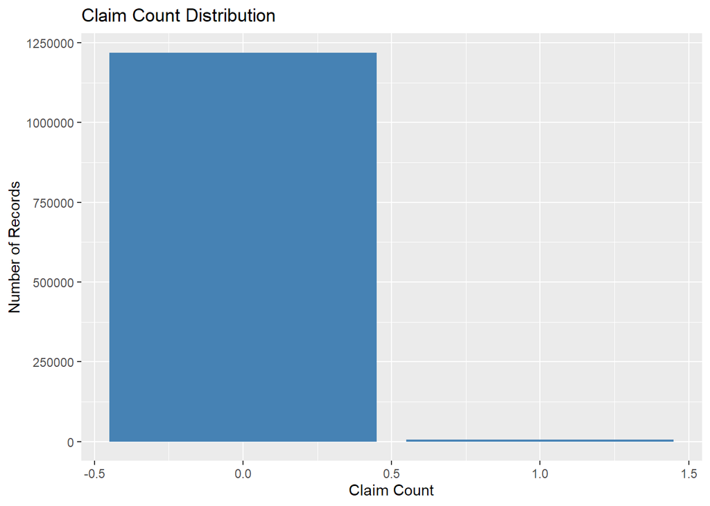

```r
# Checking distributions
# Claim count (frequency)
ggplot(claims_combined, aes(x = claim_count)) +
  geom_bar(fill = "steelblue") +
  labs(title = "Claim Count Distribution", x = "Claim Count", y = "Number of Records")
```

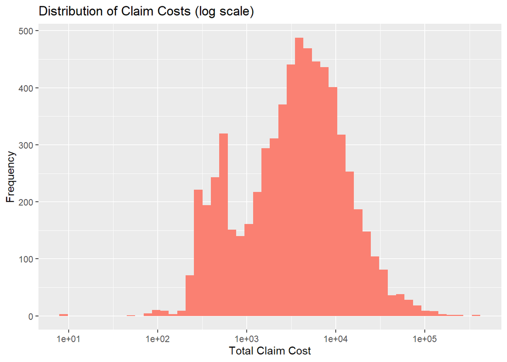

```r
# Total claims cost (severity)
ggplot(claims_combined %>% filter(claim_count > 0), aes(x = total_claims_cost)) +
  geom_histogram(fill = "salmon", bins = 50) +
  scale_x_log10() +  # log scale for skewed cost
  labs(title = "Distribution of Claim Costs (log scale)", x = "Total Claim Cost", y = "Frequency")
```

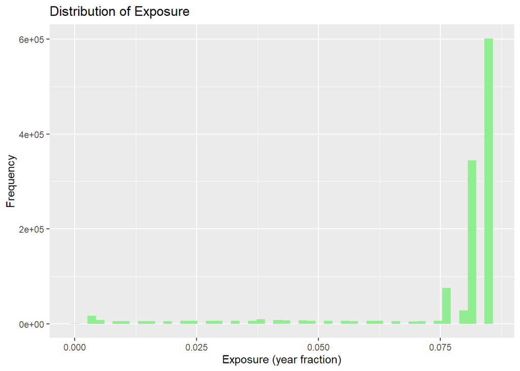

```r
# Exposure distribution
ggplot(claims_combined, aes(x = exposure)) +
  geom_histogram(fill = "lightgreen", bins = 50) +
  labs(title = "Distribution of Exposure", x = "Exposure (year fraction)", y = "Frequency")
```

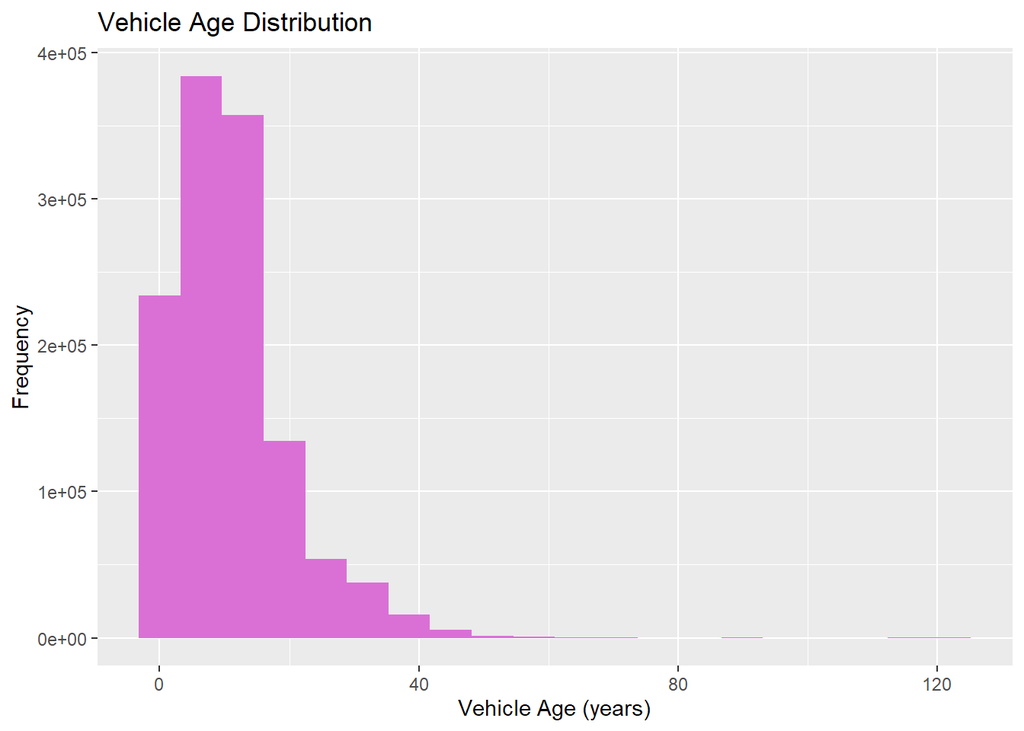

```r
# Vehicle age distribution
ggplot(claims_combined, aes(x = vehicle_age)) +
  geom_histogram(fill = "orchid", bins = 20) +
  labs(title = "Vehicle Age Distribution", x = "Vehicle Age (years)", y = "Frequency")
```

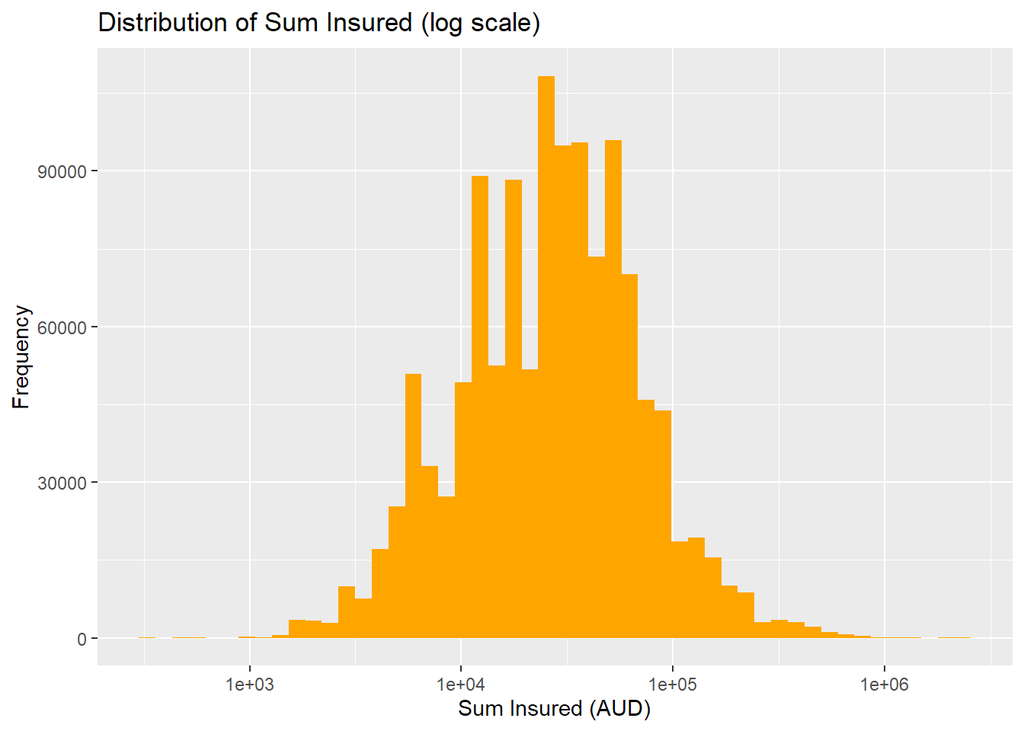

```r
# Sum insured distribution (log scale)
ggplot(claims_combined, aes(x = sum_insured)) +
  geom_histogram(fill = "orange", bins = 50) +
  scale_x_log10() +
  labs(title = "Distribution of Sum Insured (log scale)", x = "Sum Insured (AUD)", y = "Frequency")
```

Only a small proportion of claims result in non-zero costs. Specifically 0.5% only. Nonzero claims would therefore heavily skew claim cost amount. Therefore, for severity analysis, only non-zero claims are to be included whereas frequency analysis will contain the full amount.

### Categorical Variables

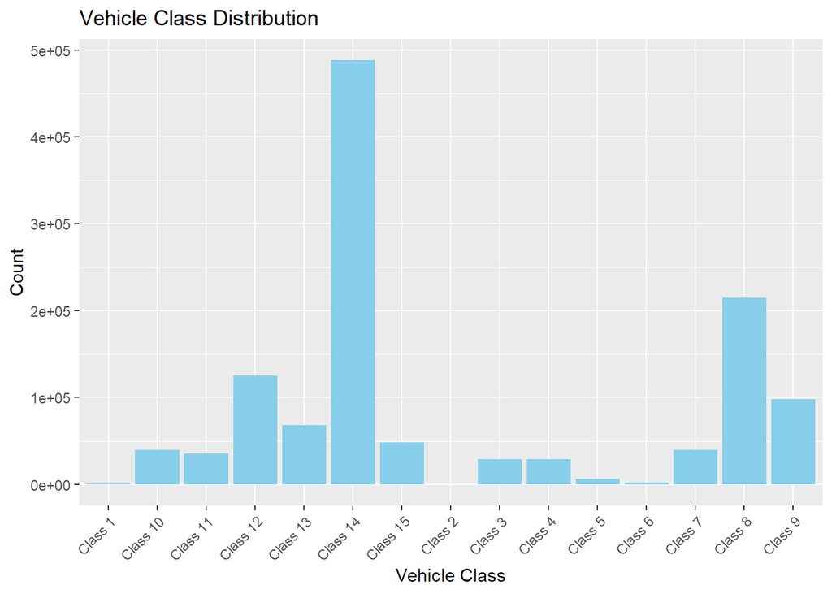

```r
# Vehicle class
ggplot(claims_combined, aes(x = vehicle_class)) +
  geom_bar(fill = "skyblue") +
  labs(title = "Vehicle Class Distribution", x = "Vehicle Class", y = "Count") +
  theme(axis.text.x = element_text(angle = 45, hjust = 1))
```

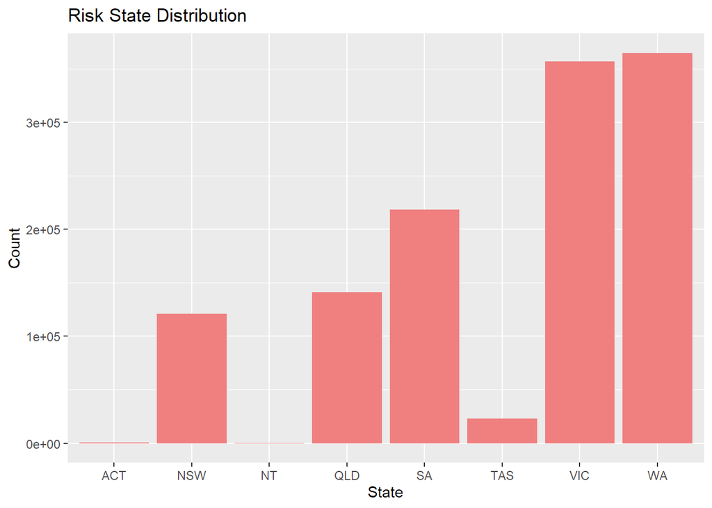

```r
# Risk state
ggplot(claims_combined, aes(x = risk_state_name)) +
  geom_bar(fill = "lightcoral") +
  labs(title = "Risk State Distribution", x = "State", y = "Count")
```

ACT, Tasmania, and Northern Territory all have significantly lower claim counts compared to other states. Especially for nonzero claims. This may result in the model in failing to encapsulate regional affects on claim severity.

### Time Trends

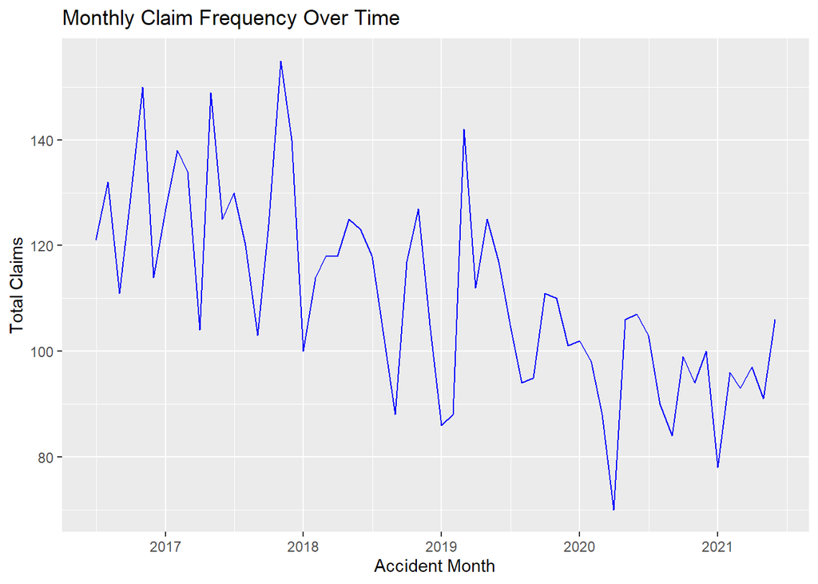

```r
# Monthly claims frequency trend
monthly_freq <- claims_combined %>%
  group_by(accident_month) %>%
  summarise(total_claims = sum(claim_count),
            avg_claim_cost = mean(total_claims_cost, na.rm = TRUE),
            avg_exposure = mean(exposure))

ggplot(monthly_freq, aes(x = accident_month, y = total_claims)) +
  geom_line(color = "blue") +
  labs(title = "Monthly Claim Frequency Over Time", x = "Accident Month", y = "Total Claims")
```

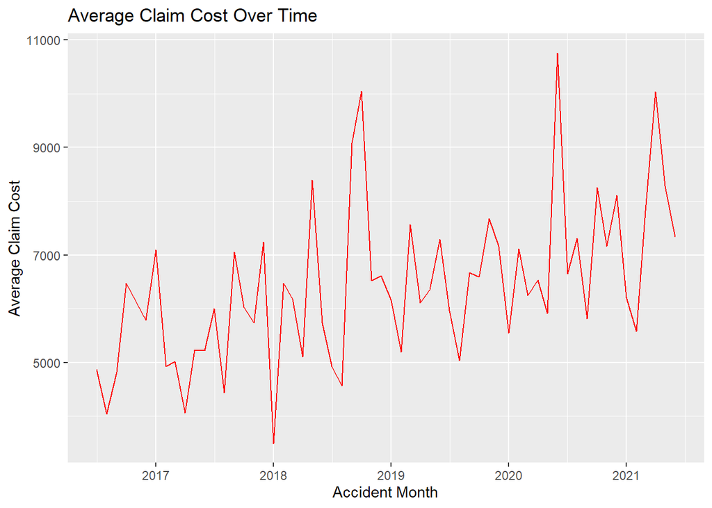

```r
ggplot(monthly_freq, aes(x = accident_month, y = avg_claim_cost)) +
  geom_line(color = "red") +
  labs(title = "Average Claim Cost Over Time", x = "Accident Month", y = "Average Claim Cost")
```

There doesn’t appear to be any blatantly obvious seasonal effects on both claim frequency and size.

### Macroeconomic Variables

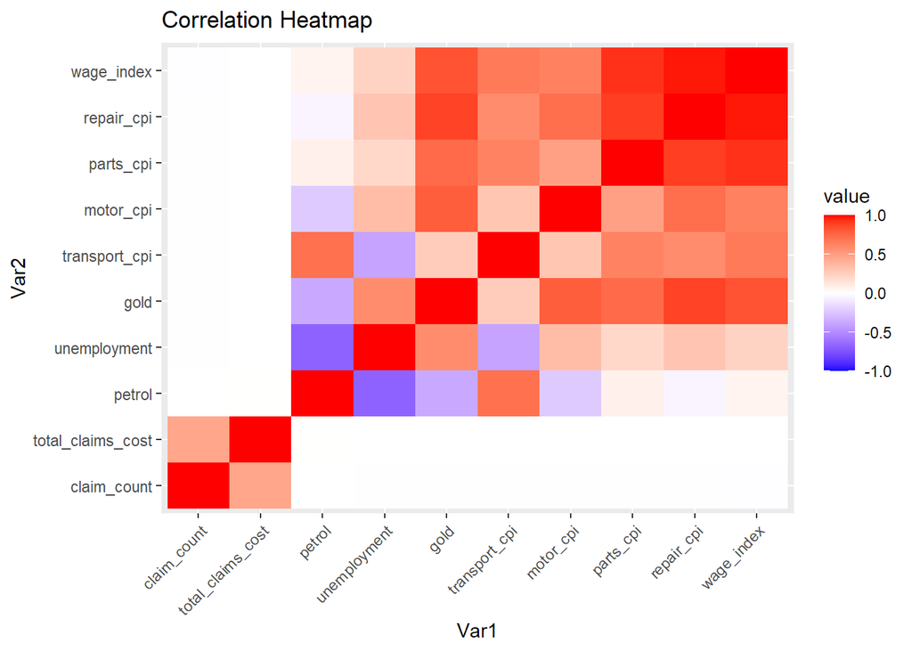

```r
macro_vars <- c("petrol", "unemployment", "gold", "transport_cpi",
                "motor_cpi", "parts_cpi", "repair_cpi", "wage_index")

# Correlation heatmap
corr_df <- claims_combined %>%
  dplyr::select(claim_count, total_claims_cost, all_of(macro_vars)) %>%
  mutate(total_claims_cost = ifelse(is.na(total_claims_cost), 0, total_claims_cost))

cor_matrix <- cor(corr_df)
corr_melt <- melt(cor_matrix)

ggplot(corr_melt, aes(x=Var1, y=Var2, fill=value)) +
  geom_tile() +
  scale_fill_gradient2(low = "blue", high = "red", mid = "white",
                       midpoint = 0, limit = c(-1,1)) +
  theme(axis.text.x = element_text(angle = 45, hjust = 1)) +
  labs(title = "Correlation Heatmap")
```

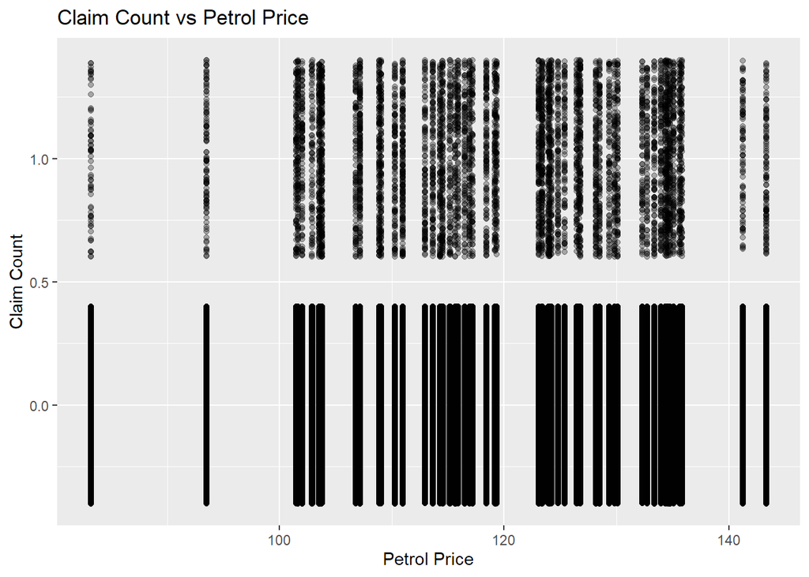

```r
# Scatterplots: claim frequency vs petrol, motor_cpi
ggplot(claims_combined, aes(x = petrol, y = claim_count)) +
  geom_jitter(alpha = 0.3) +
  labs(title = "Claim Count vs Petrol Price", x = "Petrol Price", y = "Claim Count")
```

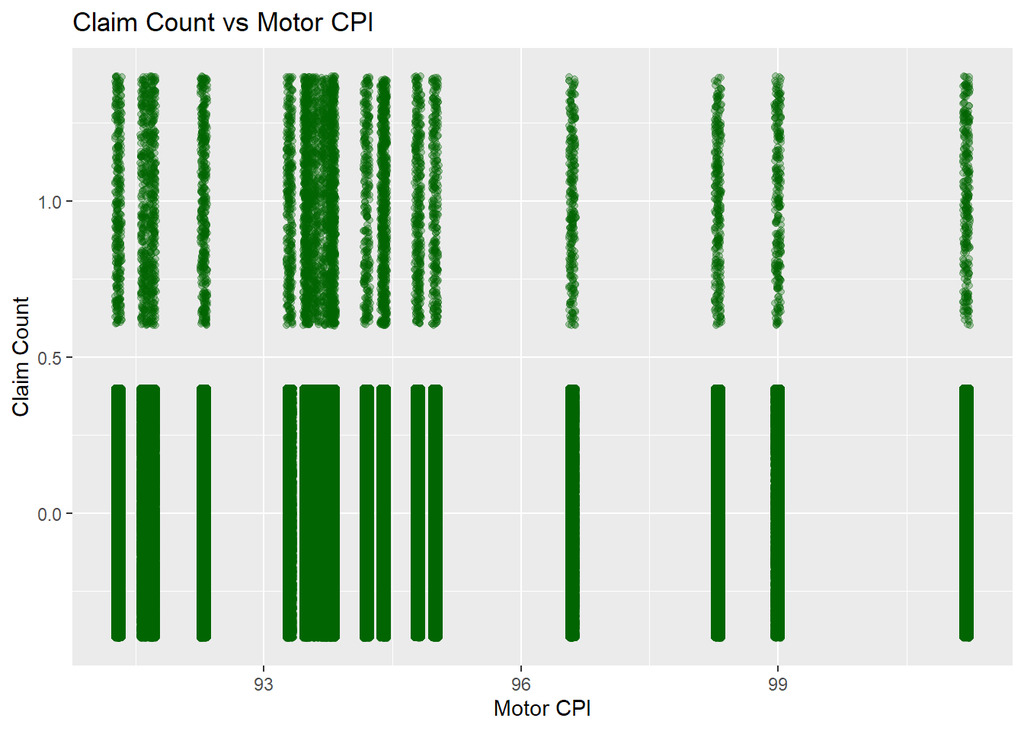

```r
ggplot(claims_combined, aes(x = motor_cpi, y = claim_count)) +
  geom_jitter(alpha = 0.3, color = "darkgreen") +
  labs(title = "Claim Count vs Motor CPI", x = "Motor CPI", y = "Claim Count")
```

### Vehicle Age

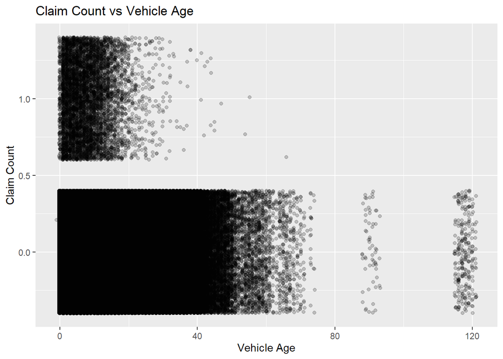

```r
# Claim count vs vehicle age
ggplot(claims_combined, aes(x = vehicle_age, y = claim_count)) +
  geom_jitter(width = 0.2, alpha = 0.2) +
  labs(title = "Claim Count vs Vehicle Age", x = "Vehicle Age", y = "Claim Count")
```

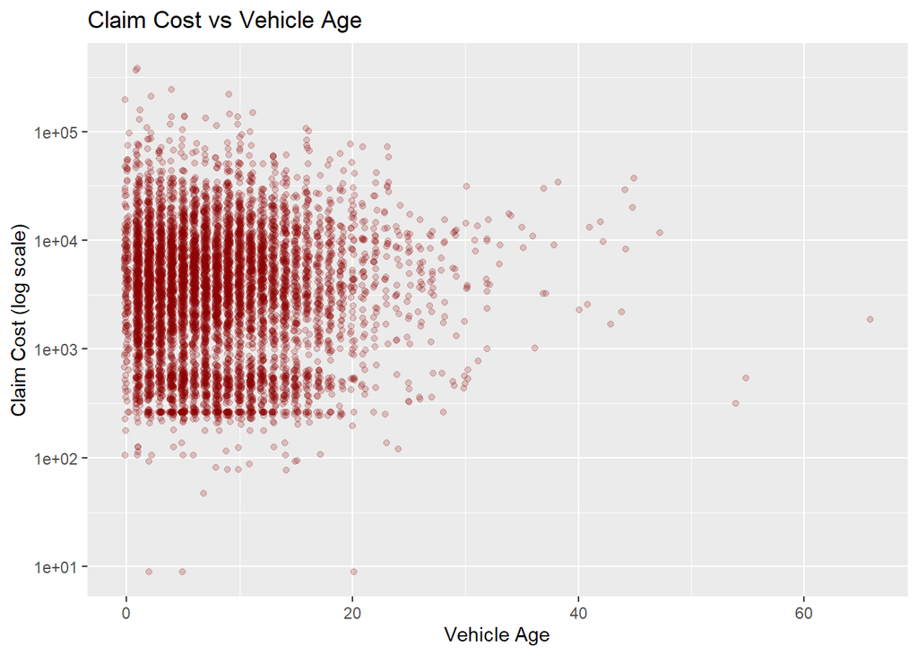

```r
# Claim cost vs vehicle age (for rows with claims)
ggplot(claims_combined %>% filter(claim_count > 0), aes(x = vehicle_age, y = total_claims_cost)) +
  geom_jitter(width = 0.2, alpha = 0.2, color = "darkred") +
  scale_y_log10() +
  labs(title = "Claim Cost vs Vehicle Age", x = "Vehicle Age", y = "Claim Cost (log scale)")
```

The jitter plot for claim count vs vehicle age actually indicates a correlation to newer vehicles with claim count. Intuitively, this can most likely be attributed to the deprecating nature of motor vehicles, although the direct cause can not be ascertained.

## Data Cleaning

### Outlier Detection

```r
claims_with_cost <- claims_combined %>% filter(claim_count > 0)

# IQR method for outlier detection
iqr_cost <- IQR(claims_with_cost$total_claims_cost, na.rm = TRUE)
q1_cost <- quantile(claims_with_cost$total_claims_cost, 0.25, na.rm = TRUE)
q3_cost <- quantile(claims_with_cost$total_claims_cost, 0.75, na.rm = TRUE)

upper_cost <- q3_cost + 1.5 * iqr_cost

# Count and proportion of outliers
outlier_summary <- claims_with_cost %>%
  filter(total_claims_cost > upper_cost) %>%
  summarise(
    outlier_count = n(),
    total_count = nrow(claims_with_cost),
    proportion = n() / nrow(claims_with_cost)
  )

print(outlier_summary)
```

```
##   outlier_count total_count proportion
## 1           534        6651 0.08028868
```

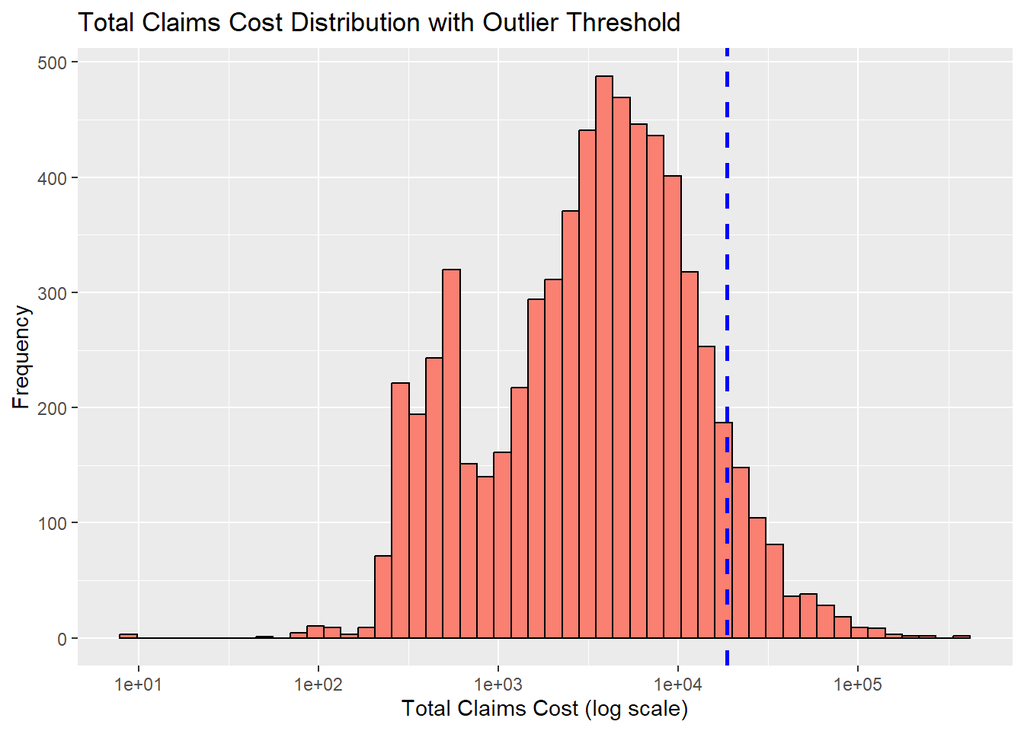

```r
# Histogram with vertical line at upper threshold
ggplot(claims_with_cost, aes(x = total_claims_cost)) +
  geom_histogram(bins = 50, fill = "salmon", color = "black") +
  scale_x_log10() +
  geom_vline(xintercept = upper_cost, color = "blue", linetype = "dashed", linewidth = 1) +
  labs(
    title = "Total Claims Cost Distribution with Outlier Threshold",
    x = "Total Claims Cost (log scale)",
    y = "Frequency"
  )
```

Outliers in nonzero claim amounts account for approximately 8% of all nonzero claim amounts. This is a non-negligible amount, and examining the histogram, removing the outliers would most likely result in poor performance in estimating large claims near the tail of the distribution. As such, the outliers were chosen to be kept in the dataset.

### Data Aggregation

Due to the low proportion of claims to total data points (0.5%). It was deciding that aggregating was more meaningful in estimating claim frequency and severity. As such, aggregating by month and risk segment was decided to be optimal.

```r
claims_agg <- claims_combined %>%
  group_by(accident_month, risk_state_name, vehicle_class) %>%
  summarise(
    total_claims = sum(claim_count, na.rm = TRUE),          # frequency
    total_cost   = sum(total_claims_cost, na.rm = TRUE),   # severity numerator
    total_exposure = sum(exposure, na.rm = TRUE),          # offset
    avg_vehicle_age = mean(vehicle_age, na.rm = TRUE),     # predictor
    avg_sum_insured = mean(sum_insured, na.rm = TRUE),     # predictor
    petrol = mean(petrol, na.rm = TRUE),
    unemployment = mean(unemployment, na.rm = TRUE),
    gold = mean(gold, na.rm = TRUE),
    transport_cpi = mean(transport_cpi, na.rm = TRUE),
    motor_cpi = mean(motor_cpi, na.rm = TRUE),
    parts_cpi = mean(parts_cpi, na.rm = TRUE),
    repair_cpi = mean(repair_cpi, na.rm = TRUE),
    wage_index = mean(wage_index, na.rm = TRUE),
    .groups = "drop"
  )
```

## Modelling

The objective of the modelling exercise is to explain the main drivers of insurance claim costs and to estimate the underlying trend in claim inflation. Because claim costs can be separated into a *frequency* component and a *severity* component, the analysis uses a traditional two-part Generalised Linear Model (GLM) structure:

1. A **frequency model** for the number of claims per policy period
2. A **severity model** for the average cost of claims.

GLMs are widely used in non-life insurance because:

- They can handle skewed, non-normal data (common in claims).
- They allow for exposure weighting.
- They provide interpretable coefficients that show the effect of each rating factor.
- They are consistent with industry practice and regulatory expectations.

Given the goal of quantifying inflation and identifying cost drivers, interpretability is more important than using complex black-box models. A GLM therefore provides the right balance of rigour and transparency.

### Model Pipeline

The following function runs a full GLM workflow in one step to increase reproducibility and reduce code redundancy.

1. **Fitting the Model -** if an offset column is provided, it takes the log of that column and includes it as an offset in the GLM. Otherwise, it fits a standard GLM with the formula and family supplied.
2. **Generate Predictions** - once fitted, the model is used to predict fitted values on the same dataset.
3. **Compute Residuals** - the function automatically determines whether the target variable is `total_claims` or `total_cost` and calculates corresponding residuals.
4. **Calculate Performance Metrics**
   1. RMSE - Root Mean Square Error, average magnitude of prediction errors, but gives more weight to large errors.
   2. MAE - Mean Absolute Error, measures average magnitude of prediction errors without squaring so all errors are weighted equally.
   3. Deviance ratio - residual deviance / degrees of freedom, a measure of goodness-of-fit. Values below 1 indicate no overdispersion relative to the assumed GLM family.
5. **Plot Predicted vs Actual -** produces a log–log scatterplot with a 45-degree reference line to visually assess fit and calibration.
6. **Return Everything**

```r
run_agg_glm_pipeline <- function(
  data,
  formula,
  family,
  offset_col = NULL,
  plot_title = NULL
) {
  # Check for offset
  if(!is.null(offset_col)) {
    data$offset_tmp <- log(data[[offset_col]])
    model <- glm(formula = formula, family = family, data = data, offset = offset_tmp)
  } else {
    model <- glm(formula = formula, family = family, data = data)
  }

  # Predictions
  if(!is.null(offset_col)) {
    data$pred <- predict(model, newdata = data, type = "response")
  } else {
    data$pred <- predict(model, newdata = data, type = "response")
  }

  # Residuals
  target_var <- if("total_cost" %in% all.vars(formula)) "total_cost" else "total_claims"
  data$residual <- data[[target_var]] - data$pred

  # Metrics
  rmse <- sqrt(mean(data$residual^2, na.rm = TRUE))
  mae  <- mean(abs(data$residual), na.rm = TRUE)
  deviance_ratio <- model$deviance / model$df.residual

  cat("RMSE:", rmse, "\n")
  cat("MAE:", mae, "\n")
  cat("Deviance / DF:", deviance_ratio, "\n")

  # Plot predicted vs actual
  p <- ggplot(data, aes(x = pred, y = .data[[target_var]])) +
    geom_point(alpha = 0.5) +
    geom_abline(intercept = 0, slope = 1, color = "red") +
    scale_x_log10() +
    scale_y_log10() +
    labs(
      title = ifelse(is.null(plot_title), "Predicted vs Actual", plot_title),
      x = "Predicted",
      y = "Actual"
    )

  print(p)

  list(
    model = model,
    data = data,
    metrics = list(rmse = rmse, mae = mae, deviance_ratio = deviance_ratio),
    plot = p
  )
}
```

### Frequency model

Claim frequency is modelled using a GLM with a log link and a Poisson or Negative Binomial distribution. The Poisson distribution is the standard starting point for count data, but we check for over-dispersion. If over-dispersion is present, the Negative Binomial form provides a better fit.

The model predicts the expected number of claims per policy, adjusted for exposure.

The output of this model gives multiplicative relativities that show how each factor affects the likelihood of a claim.

```
## RMSE: 1.226365
## MAE: 0.5550319
## Deviance / DF: 0.6779407
```

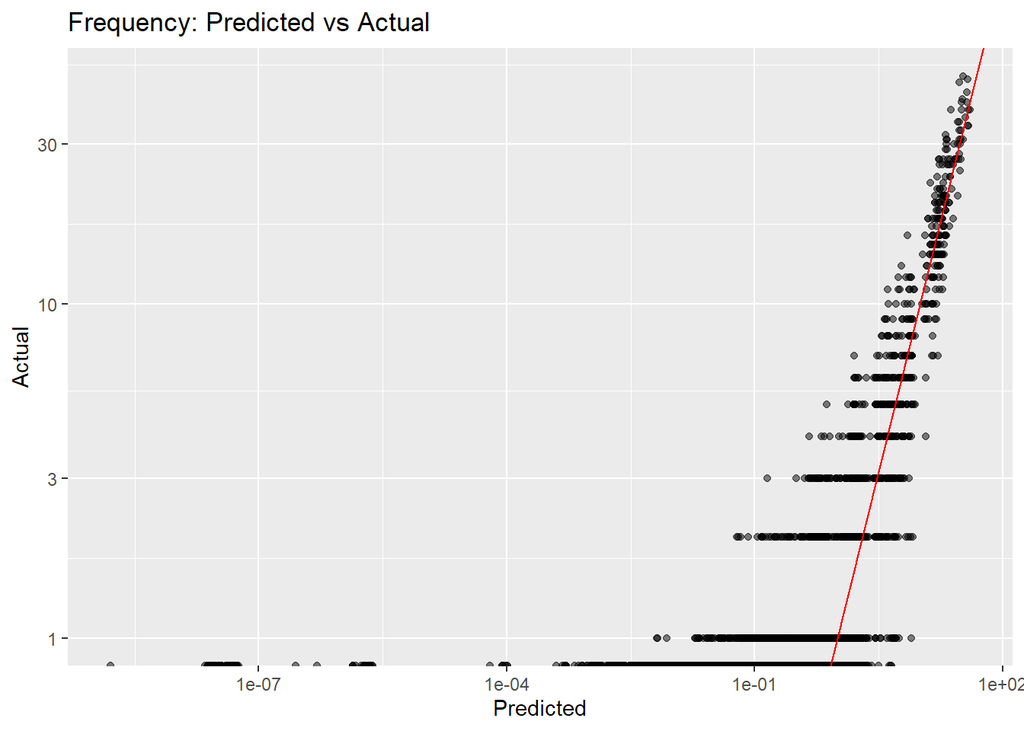

```r
freq_formula <- total_claims ~ avg_vehicle_age + vehicle_class + risk_state_name +
                avg_sum_insured + petrol + unemployment + gold +
                transport_cpi + motor_cpi + parts_cpi + repair_cpi + wage_index

freq_results <- run_agg_glm_pipeline(
  data = claims_agg,
  formula = freq_formula,
  family = poisson(),
  offset_col = "total_exposure",
  plot_title = "Frequency: Predicted vs Actual"
)
```

```r
freq_model <- freq_results$model

# Metrics
freq_results$metrics
```

```
## $rmse
## [1] 1.226365
##
## $mae
## [1] 0.5550319
##
## $deviance_ratio
## [1] 0.6779407
```

```r
summary(freq_model)
```

```
##
## Call:
## glm(formula = formula, family = family, data = data, offset = offset_tmp)
##
## Coefficients:
##                         Estimate Std. Error z value Pr(>|z|)
## (Intercept)           -1.565e+00  1.695e+00  -0.924 0.355646
## avg_vehicle_age       -1.103e-01  1.974e-02  -5.588 2.29e-08 ***
## vehicle_classClass 10 -1.102e+00  5.956e-01  -1.851 0.064169 .
## vehicle_classClass 11 -3.608e-01  6.149e-01  -0.587 0.557388
## vehicle_classClass 12  1.008e-01  5.869e-01   0.172 0.863650
## vehicle_classClass 13  8.734e-02  5.870e-01   0.149 0.881716
## vehicle_classClass 14  9.701e-02  5.972e-01   0.162 0.870948
## vehicle_classClass 15 -2.031e+00  6.137e-01  -3.309 0.000935 ***
## vehicle_classClass 2  -1.006e+01  2.394e+02  -0.042 0.966484
## vehicle_classClass 3  -1.929e-01  6.109e-01  -0.316 0.752168
## vehicle_classClass 4  -1.765e+00  6.171e-01  -2.860 0.004232 **
## vehicle_classClass 5  -2.011e+00  7.000e-01  -2.872 0.004074 **
## vehicle_classClass 6  -5.290e-01  7.334e-01  -0.721 0.470708
## vehicle_classClass 7  -2.280e+00  6.221e-01  -3.665 0.000247 ***
## vehicle_classClass 8  -1.739e+00  5.939e-01  -2.928 0.003415 **
## vehicle_classClass 9  -1.791e+00  5.955e-01  -3.007 0.002640 **
## risk_state_nameNSW    -3.649e-01  2.922e-01  -1.249 0.211785
## risk_state_nameNT     -6.551e-01  7.641e-01  -0.857 0.391239
## risk_state_nameQLD    -5.343e-01  2.963e-01  -1.803 0.071337 .
## risk_state_nameSA     -2.368e-01  2.980e-01  -0.795 0.426795
## risk_state_nameTAS    -2.322e-01  3.228e-01  -0.719 0.471871
## risk_state_nameVIC    -4.785e-01  2.945e-01  -1.625 0.104212
## risk_state_nameWA     -2.574e-02  2.958e-01  -0.087 0.930661
## avg_sum_insured        5.866e-06  2.504e-06   2.342 0.019156 *
## petrol                 4.619e-03  2.617e-03   1.765 0.077523 .
## unemployment           4.869e-02  3.542e-02   1.375 0.169223
## gold                  -1.468e-04  1.982e-04  -0.741 0.458938
## transport_cpi         -5.259e-03  1.354e-02  -0.388 0.697768
## motor_cpi              1.032e-02  1.070e-02   0.964 0.334805
## parts_cpi              1.377e-02  1.745e-02   0.789 0.429979
## repair_cpi             2.396e-02  2.542e-02   0.943 0.345926
## wage_index            -3.685e-02  2.657e-02  -1.387 0.165553
## ---
## Signif. codes:  0 '***' 0.001 '**' 0.01 '*' 0.05 '.' 0.1 ' ' 1
##
## (Dispersion parameter for poisson family taken to be 1)
##
##     Null deviance: 7147.9  on 5034  degrees of freedom
## Residual deviance: 3391.7  on 5003  degrees of freedom
## AIC: 7560.5
##
## Number of Fisher Scoring iterations: 14
```

Examining the fit. RMSE of 1.23 claims per month and MAE is alright, with most variation being captured. Examining the graph, indicates that the model is performing better for larger counts with a larger spread of predicted values for smaller actual values. Values for deviance / DF are below 1 indicating no over-dispersion, this means that the Poisson assumption seems reasonable for modelling frequency. Negative Binomial was an alternative if over-dispersion was present.

The main strong predictors are average vehicle age, vehicle class, and sum insured.

- Positive coefficient for sum insured indicates that larger sum insured corresponds to larger claim counts but the smaller positive value for the estimate indicate the effect size is minimal.
- Average vehicle age makes sense as well and aligns with the exploratory data analysis conducted earlier where a large majority of claims came from newer cars. The negative coefficient agrees with the analysis conducted prior. This can most likely be attributed to older cars being tend to be driven less or more cautiously, or perhaps a correlation between older cars and safer drivers.
- Some particular vehicle classes have significant negative coefficients, indicating lower claim frequencies compared the baseline class. Perhaps there is a correlation between the durability of those vehicle classes or the types of drivers. However it is critical to note the imbalance of vehicle classes in the exploratory data analysis. The vehicle classes with critical p-values also correspond to some of the more numerous vehicle classes in the dataset in general. If a larger proportion of vehicles belong to those particular classes, the model or data even may be correspondingly skewed to favour those claims. Thus, the relationship between vehicle class and claim frequency can be a good correlation, but may not directly reflect whether or not those classes contribute to increased claim frequencies.

Economic indicators (unemployment, gold, CPI categories, wage index) all have non-significant coefficients, suggesting they do not materially influence claim frequency at this aggregated level. Risk state variables (except QLD showing borderline effect) also show weak or no impact. This makes sense as those factors are unlikely to affect the number of vehicles on the road and therefore the corresponding number of accidents.

### Severity Model

Claim severity is modelled using a GLM with a log link and a Gamma distribution.  
The Gamma family is appropriate because claim amounts are continuous, positive, and right-skewed.

Predictors in the severity model often overlap with the frequency model, but the effects are not necessarily the same. For example, drivers with older cars might not claim more often, but their claims might cost more when they do.

```
## RMSE: 28923.6
## MAE: 16178.3
## Deviance / DF: 0.7757364
```

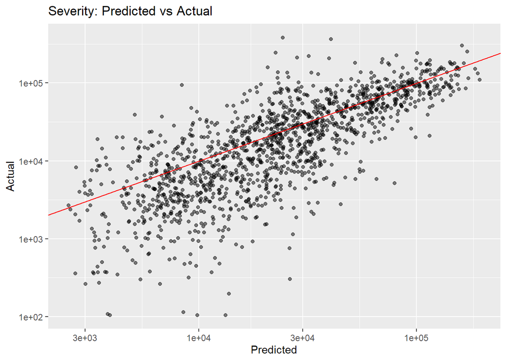

```r
sev_formula <- total_cost ~ avg_vehicle_age + vehicle_class + risk_state_name +
               avg_sum_insured + petrol + unemployment + gold +
               transport_cpi + motor_cpi + parts_cpi + repair_cpi + wage_index

sev_results <- run_agg_glm_pipeline(
  data = claims_agg %>% filter(total_cost > 0),
  formula = sev_formula,
  family = Gamma(link = "log"),
  offset_col = "total_claims",
  plot_title = "Severity: Predicted vs Actual"
)
```

```r
sev_model <- sev_results$model

# Metrics
sev_results$metrics
```

```
## $rmse
## [1] 28923.6
##
## $mae
## [1] 16178.3
##
## $deviance_ratio
## [1] 0.7757364
```

```r
summary(sev_model)
```

```
##
## Call:
## glm(formula = formula, family = family, data = data, offset = offset_tmp)
##
## Coefficients:
##                         Estimate Std. Error t value Pr(>|t|)
## (Intercept)            1.133e+01  3.581e+00   3.162  0.00160 **
## avg_vehicle_age        1.644e-02  3.207e-02   0.513  0.60836
## vehicle_classClass 10  8.374e-01  6.416e-01   1.305  0.19202
## vehicle_classClass 11  1.290e+00  6.759e-01   1.909  0.05641 .
## vehicle_classClass 12 -2.668e-01  6.383e-01  -0.418  0.67603
## vehicle_classClass 13  1.055e-02  6.322e-01   0.017  0.98669
## vehicle_classClass 14 -7.534e-01  6.665e-01  -1.130  0.25847
## vehicle_classClass 15 -1.317e+00  6.748e-01  -1.951  0.05126 .
## vehicle_classClass 3  -2.112e-01  6.723e-01  -0.314  0.75343
## vehicle_classClass 4  -6.954e-01  6.790e-01  -1.024  0.30598
## vehicle_classClass 5  -1.327e-01  7.826e-01  -0.170  0.86535
## vehicle_classClass 6  -9.578e-01  7.889e-01  -1.214  0.22490
## vehicle_classClass 7   4.767e-01  6.891e-01   0.692  0.48918
## vehicle_classClass 8   5.640e-01  6.505e-01   0.867  0.38610
## vehicle_classClass 9  -3.369e-01  6.506e-01  -0.518  0.60460
## risk_state_nameNSW     6.802e-01  3.497e-01   1.945  0.05194 .
## risk_state_nameNT     -4.276e-01  8.304e-01  -0.515  0.60664
## risk_state_nameQLD     3.568e-01  3.558e-01   1.003  0.31614
## risk_state_nameSA      2.077e-01  3.656e-01   0.568  0.56993
## risk_state_nameTAS    -1.689e-01  3.981e-01  -0.424  0.67149
## risk_state_nameVIC     5.088e-01  3.534e-01   1.440  0.15018
## risk_state_nameWA      7.661e-02  3.576e-01   0.214  0.83040
## avg_sum_insured       -6.182e-06  3.464e-06  -1.785  0.07451 .
## petrol                 1.665e-02  5.800e-03   2.870  0.00417 **
## unemployment          -6.948e-02  8.097e-02  -0.858  0.39101
## gold                   3.634e-04  4.418e-04   0.823  0.41092
## transport_cpi         -7.946e-02  3.041e-02  -2.613  0.00908 **
## motor_cpi             -1.143e-02  2.348e-02  -0.487  0.62653
## parts_cpi             -1.990e-02  3.937e-02  -0.505  0.61331
## repair_cpi             2.940e-02  5.648e-02   0.521  0.60272
## wage_index             2.924e-02  5.830e-02   0.502  0.61607
## ---
## Signif. codes:  0 '***' 0.001 '**' 0.01 '*' 0.05 '.' 0.1 ' ' 1
##
## (Dispersion parameter for Gamma family taken to be 1.133894)
##
##     Null deviance: 1678.7  on 1457  degrees of freedom
## Residual deviance: 1107.0  on 1427  degrees of freedom
## AIC: 32035
##
## Number of Fisher Scoring iterations: 8
```

Overall, the model captures some structure but a large amount of unexplained variation is expected. Severity is always more volatile than frequency.

- Petrol price is a moderately positive coefficient, indicating higher petrol prices leads to higher claims. A possible reasoning is that higher petrol costs may reflect broader inflationary pressure, and could therefore proxy economic conditions that increase repair and labour expenses. This would consequentially drive up the claim costs.
- Transport CPI is a negative coefficient. Considering that transport CPI covers things like fuel costs, vehicle maintenance and running costs, but also public transport costs, this seems counter intuitive as repair, replacement part, and labour costs increase. Furthermore, increases in public transport fees would redirect commuters to travel more via private vehicles, increasing road traffic and the chance of motor incidents to occur. As such, it is important to consider other variables at play, such as CPI variables being colinear or aggregation effects causing instability. Furthermore exploration may need to be conducted to examine the true relationship between claim severity and transport CPI.

Other features tend to have minimal to no effect on claim size. One key variable to note is average sum insured, which you’d believe would be directly correlated to the claim severity. However, considering that it has a borderline p-value (close to 5%), but also a negative coefficient (which indicates the lesser the sum insured, the greater the claim cost). Such a counter intuitive relationship could be a result of aggregated data distorting the results, or perhaps a reflection of individual tendency to have a greater sum insured to more expensive vehicles, and individuals thereby treating the vehicles with more care.

## Conclusion

The GLM modelling of claim frequency and severity captures the general trends in monthly motor claims but struggles with extreme values and tail behaviour. Key findings include:

- **Frequency:** Average vehicle age, vehicle class, and sum insured are the strongest predictors. Macroeconomic indicators and state-level variables generally have minimal impact.
- **Severity:** Petrol price, transport CPI, and average sum insured show some influence, though effects are modest and occasionally counter-intuitive due to aggregation effects.
- **Model limitations:** Rare and extreme claims are underrepresented, and short-term macroeconomic factors provide limited explanatory power at the aggregated level.

Overall, classical GLMs are appropriate for capturing central trends and providing interpretable insights but are less effective at predicting tail events. Future improvements could involve time-series models, target transformations, or hybrid approaches to better account for extreme claims and seasonality.